# Forte Hotel Design

Krishanthi Weragalaarachchi

7/20/2021

```r
your_name <- readline(prompt = "What is your name?      ")
```

```
## What is your name?
```

```r
print(your_name)
```

```
## [1] ""
```

```r
print(params$Name)
```

```
## [1] "Krishanthi Weragalaarachchi"
```

```r
date()
```

```
## [1] "Tue Jul 27 22:36:23 2021"
```

I have a mac and following code was run to get the IP address

```r
x <- system("ifconfig", intern=TRUE)
z <- x[grep("\tinet", x)]
gsub(".*? ([:digit:])", "\\1", z[5])
```

```
## [1] "\tinet 192.168.86.29 netmask 0xffffff00 broadcast 192.168.86.255"
```

## Data Setup

installing libraries, set the directory and read the data

```r
library(cluster)
library(conjoint)
library(dplyr)
library(fpc)
library(broom)
library(ggplot2)
library(tidyverse)
```

```r
setwd("/Users/krishanthi/Documents/KSU/MANGT880/Project")
bundles_data <- read.csv("bundles.csv")
design_data <-  read.csv("design.csv")
ratings_data <- read.csv("ratings.csv")
existing_prof_data <- read.csv("existing_profiles.csv")
new_prof_data <- read.csv("new_profiles.csv")
```

remove attributes column from each dataset

```r
design <- design_data[,-1]
design
```

```
##           Level01       Level02                Level03   Level04
## 1     Small_Suite    Large_Room            Room_Office
## 2 Internet_access Speaker_phone               Room_fax
## 3   Exercise_room          Pool Exercise_room_and_Pool
## 4      Shoe_shine  Tape_library       Fruit_and_cheese Newspaper
## 5             Yes            No
```

```r
ratings <- ratings_data[,-1]
head(ratings)
```

```
##   Bundle01 Bundle02 Bundle03 Bundle04 Bundle05 Bundle06 Bundle07 Bundle08
## 1       56       48       31       47       24       69       34       22
## 2       25       58       49       71       58       63       38       36
## 3       67        2       53       16       67       46       39       34
## 4       38       64       50       69       50       49       57       27
## 5       64       47       83       52       73       21       66       17
## 6       43       50       32       36       56       32       46       20
##   Bundle09 Bundle10 Bundle11 Bundle12 Bundle13 Bundle14 Bundle15 Bundle16
## 1       28       30       76       36       27       16       29       58
## 2       34       52       38       80       49       74       13       58
## 3       43       31       49       38       55       61       35       53
## 4       29       22       58       33       70       24       71       30
## 5       66       43       57       57       69       47       52       34
## 6       84        5       46       18       73       17       36       31
```

```r
bundles <- data.frame(bundles_data[,-1])
existing <- data.frame(existing_prof_data[,-1])
new <- data.frame(new_prof_data[,-1])
```

making of data sets with codes

```r
replace_1 <- c("Small_Suite","Internet_access","Exercise_room","Shoe_shine","Yes")
replace_2 <- c("Large_Room" ,"No", "Pool" ,"Speaker_phone" ,"Tape_library")
replace_3 <- c("Exercise_room_and_Pool", "Fruit_and_cheese", "Room_fax", "Room_Office")
replace_4 <- c("Newspaper")

bundles <- as.data.frame(sapply(bundles, function(x)
  gsub(paste0(replace_3, collapse = '|'), 3, x)))
bundles <- as.data.frame(sapply(bundles, function(x)
  gsub(paste0(replace_1, collapse = '|'), 1, x)))
bundles <- as.data.frame(sapply(bundles, function(x)
  gsub(paste0(replace_2, collapse = '|'), 2, x)))
bundles <- as.data.frame(sapply(bundles, function(x)
  gsub(paste0(replace_4, collapse = '|'), 4, x)))
bundles <- data.frame(t(bundles))
bundles <- bundles %>% rename("Room" = X1, "Bus_Amenities" = X2, "Leisure" = X3, "Extras" =X4, "Rest_Delivery" =X5)
row.names(bundles) <-NULL
bundles
```

```
##    Room Bus_Amenities Leisure Extras Rest_Delivery
## 1     1             1       1      1             1
## 2     2             2       3      1             2
## 3     3             3       2      1             1
## 4     2             2       2      1             2
## 5     1             2       2      2             1
## 6     2             1       2      2             2
## 7     3             2       3      2             1
## 8     2             3       1      2             2
## 9     1             3       3      3             2
## 10    2             2       1      3             1
## 11    3             1       2      3             2
## 12    2             2       2      3             1
## 13    1             2       2      4             2
## 14    2             3       2      4             1
## 15    3             2       1      4             2
## 16    2             1       3      4             1
```

```r
existing <- as.data.frame(sapply(existing, function(x)
  gsub(paste0(replace_3, collapse = '|'), 3, x)))
existing <- as.data.frame(sapply(existing, function(x)
  gsub(paste0(replace_1, collapse = '|'), 1, x)))
existing <- as.data.frame(sapply(existing, function(x)
  gsub(paste0(replace_2, collapse = '|'), 2, x)))
existing <- as.data.frame(sapply(existing, function(x)
  gsub(paste0(replace_4, collapse = '|'), 4, x)))
existing <- data.frame(t(existing))
existing <- existing %>% rename("Room" = X1, "Bus_Amenities" = X2, "Leisure" = X3, "Extras" =X4, "Rest_Delivery" =X5)
row.names(existing) <-NULL
existing
```

```
##   Room Bus_Amenities Leisure Extras Rest_Delivery
## 1    1             2       3      4             1
## 2    2             2       1      4             1
## 3    2             2       1      2             2
## 4    1             2       3      4             2
## 5    3             3       3      1             1
```

```r
new <- as.data.frame(sapply(new, function(x)
  gsub(paste0(replace_3, collapse = '|'), 3, x)))
new <- as.data.frame(sapply(new, function(x)
  gsub(paste0(replace_1, collapse = '|'), 1, x)))
new <- as.data.frame(sapply(new, function(x)
  gsub(paste0(replace_2, collapse = '|'), 2, x)))
new <- as.data.frame(sapply(new, function(x)
  gsub(paste0(replace_4, collapse = '|'), 4, x)))
new <- data.frame(t(new))
new <- new %>% rename("Room" = X1, "Bus_Amenities" = X2, "Leisure" = X3, "Extras" =X4, "Rest_Delivery" =X5)
row.names(new) <-NULL
new
```

```
##   Room Bus_Amenities Leisure Extras Rest_Delivery
## 1    3             1       1      3             2
## 2    1             3       1      2             1
## 3    2             2       3      2             2
## 4    2             1       3      2             1
```

levelnames dataframe

```r
levelnames <-data.frame(levels=c("Small_Suite", "Large_Room", "Room_Office",
                                 "Internet_access","Speaker_phone","Room_fax",
                                 "Exercise_room","Pool", "Exercise_room_and_Pool",
                                 "Shoe_shine", "Tape_library","Fruit_and_cheese","Newspaper",
                                 "Yes", "No"))
```

## Conjoit Analysis

Measurement of part-worths utilities (all respondents):

```r
part_utilities=caPartUtilities(y=ratings,x=bundles,z=levelnames)
print(head(part_utilities))
```

```
##      intercept Small_Suite Large_Room Room_Office Internet_access Speaker_phone
## [1,]    40.250      -5.250      1.750       3.500          23.625        -6.750
## [2,]    41.458      -4.333     15.667     -11.333          -2.875         3.500
## [3,]    46.583      12.292    -10.583      -1.708           8.125       -10.250
## [4,]    44.417      -1.750     -8.750      10.500           0.167        10.917
## [5,]    54.500      10.583    -17.667       7.083          -7.542         5.833
## [6,]    43.167      20.625    -17.250      -3.375          -0.750         1.250
##      Room_fax Exercise_room   Pool Exercise_room_and_Pool Shoe_shine
## [1,]  -16.875        -4.750  1.750                  3.000      6.062
## [2,]   -0.625       -14.750 14.000                  0.750      1.000
## [3,]    2.125         0.375  6.750                 -7.125     -8.562
## [4,]  -11.083        -5.458  5.417                  0.042      8.937
## [5,]    1.708        -7.542  5.833                  1.708      8.500
## [6,]   -0.500       -13.167 -0.417                 13.583      1.187
##      Tape_library Fruit_and_cheese Newspaper    Yes     No
## [1,]       -2.188            3.063    -6.938 -3.813  3.813
## [2,]       -1.000            1.250    -1.250  4.500 -4.500
## [3,]        3.438           -2.813     7.938  8.063 -8.063
## [4,]       -0.563          -10.812     2.438 -8.313  8.313
## [5,]       -8.750            2.750    -2.500  5.375 -5.375
## [6,]       -0.563           -0.812     0.188 -8.063  8.063
```

```r
#write.csv(part_utilities,"part_utilities_all_respondents.csv")
```

levelnames of maximum part_utilities for each respondent

```r
colnames(part_utilities[,-1])[max.col(part_utilities[,-1])]
```

```
##  [1] "Internet_access"        "Large_Room"             "Small_Suite"
##  [4] "Speaker_phone"          "Small_Suite"            "Small_Suite"
##  [7] "Exercise_room_and_Pool" "Room_fax"               "Fruit_and_cheese"
## [10] "Exercise_room_and_Pool" "Exercise_room"          "Room_Office"
## [13] "Shoe_shine"             "Exercise_room"          "Large_Room"
## [16] "Exercise_room_and_Pool" "Room_Office"            "Small_Suite"
## [19] "Room_fax"               "Room_Office"            "Small_Suite"
## [22] "Speaker_phone"          "Speaker_phone"          "Small_Suite"
## [25] "Fruit_and_cheese"       "Shoe_shine"             "Small_Suite"
## [28] "Room_Office"            "Small_Suite"            "Room_fax"
## [31] "Room_fax"               "Large_Room"             "Exercise_room_and_Pool"
## [34] "Room_fax"               "Small_Suite"            "Fruit_and_cheese"
## [37] "Room_Office"            "Exercise_room_and_Pool" "Large_Room"
## [40] "Shoe_shine"
```

Measurement of total utilities (all respondents):

```r
total_utilities=caTotalUtilities(y=ratings,x=bundles)
print(head(total_utilities))
```

```
##        [,1]   [,2]   [,3]   [,4]   [,5]  [,6]   [,7]   [,8]   [,9]  [,10]
## [1,] 56.125 48.125 30.875 46.875 24.000 69.00 34.000 22.000 28.000 29.750
## [2,] 25.000 57.875 49.000 71.125 58.125 62.75 37.875 36.250 34.000 51.625
## [3,] 66.875  2.000 53.250 15.875 66.875 46.25 39.000 33.875 43.000 31.375
## [4,] 38.000 63.875 49.875 69.250 50.125 49.00 57.000 26.875 29.125 22.000
## [5,] 63.875 47.500 83.000 51.625 73.375 21.00 65.750 16.875 65.875 43.250
## [6,] 43.000 50.000 32.000 36.000 56.000 32.25 46.000 19.750 84.125  5.125
##       [,11]  [,12]  [,13]  [,14]  [,15]  [,16]
## [1,] 76.000 36.250 26.875 16.125 29.125 57.875
## [2,] 38.000 80.375 48.875 73.750 13.125 58.250
## [3,] 48.875 37.750 55.250 60.875 34.875 53.000
## [4,] 58.000 32.875 69.750 24.125 71.125 30.000
## [5,] 57.250 56.625 68.875 47.250 52.000 33.875
## [6,] 45.875 17.875 72.875 17.125 36.125 30.875
```

```r
# write.csv(total_utilities,"total_utilities_all_respondents.csv")
```

Frequency of bundle choice

```r
bundle_names <-unlist(apply(total_utilities, 1, function(x) which(x == max(x)))) # bundle choice for each respondent
Bundle_choice <- data.frame(table(bundle_names)) # buying frequency for each bundle
#write.csv(Bundle_choice,"choices_for_16bundles.csv")
Bundle_choice
```

```
##    bundle_names Freq
## 1             1    3
## 2             2    2
## 3             3    6
## 4             4    1
## 5             5    2
## 6             6    1
## 7             7    1
## 8             8    2
## 9             9    6
## 10           10    3
## 11           11    3
## 12           12    2
## 13           13    1
## 14           14    2
## 15           15    4
## 16           16    2
```

importance of attributes (considering all respondents)

```r
importance_all=caImportance(y=ratings,x=bundles)
print(importance_all)
```

```
## [1] 29.20 21.32 19.74 15.94 13.80
```

###impoartant: In mac, qurtz opens up for bitmap image rendering for Conjoint(). Then later causes trouble opening plot preview for other plots for some reason. Aslo this causes R to stop when knitting to HTML. I did not have time to figure out a way to avoid that. Only happens in Rmarkdown. all plots generated using R are included in the report.

```r
#Conjoint(y=ratings,x=bundles,z=levelnames)
```

Beta coefficients or partwoth utility from the model for all respondents

```r
partworth_all <- data.frame('intercept' = 43.69, "Small_Suite"=3,"Large_Room"= -3.2438,
                                  "Room_Office" = 0.2438, "Internet_access" = -1.4687,
                                  "Speaker_phone"=0.9063, "Room_fax"=0.5625,"Exercise_room"=-0.9979,
                                  "Pool"=0.3896,"Exercise_room_and_Pool"=0.6083,"Shoe_shine"=0.1047,
                                  "Tape_library"=-1.2641,"Fruit_and_cheese"=0.8859,"Newspaper"=0.2734,
                                  "Yes"=0.0078,"No"=-0.0078)
partworth_all
```

```
##   intercept Small_Suite Large_Room Room_Office Internet_access Speaker_phone
## 1     43.69           3    -3.2438      0.2438         -1.4687        0.9063
##   Room_fax Exercise_room   Pool Exercise_room_and_Pool Shoe_shine Tape_library
## 1   0.5625       -0.9979 0.3896                 0.6083     0.1047      -1.2641
##   Fruit_and_cheese Newspaper    Yes      No
## 1           0.8859    0.2734 0.0078 -0.0078
```

function to calculate preferance-share for each respondent

```r
Preference_share <- function(partworths,simulations) {
  for (j in seq(1:length(colnames(simulations[,-1])))) {
    mylist<- c()
    for (i in seq(1:length(colnames(partworths)))) {
      coln <- colnames(partworths)[i]
      if (coln %in% simulations[,j] || coln == "intercept"){
        mylist<- c(mylist,coln)
        pat <- quo_name(enquo(j))
        newN <- paste0(pat, "_sum")
        newPref <-partworths %>%
          select(all_of(mylist)) %>%
          reduce(`+`)
        partworths<-partworths %>%
          mutate(!!newN := newPref)
      }
    }
  }
  new_preferances<-partworths[,17:ncol(partworths)]
  return( new_preferances)
}
```

```r
Preference_share(partworth_all,bundles_data[,-1])
```

```
##     1_sum   2_sum   3_sum  4_sum   5_sum   6_sum   7_sum   8_sum   9_sum
## 1 44.3359 42.0577 44.9984 41.839 46.7296 38.0952 44.1921 38.7389 48.7389
##    10_sum  11_sum  12_sum  13_sum  14_sum  15_sum
## 1 41.2483 43.7328 42.6358 48.2515 41.6795 44.1078
```

the relative importance of features (for the respondent named Nissa):

```r
importance_nissa=caImportance(y=ratings[26,],x=bundles)
print(importance_nissa)
```

```
## [1] 21.94 21.94 12.08 23.85 20.19
```

###impoartant: In mac, qurtz opens up for bitmap image rendering for Conjoint(). Then later causes trouble opening plot preview for other plots for some reason. Aslo this causes R to stop when knitting to HTML. I did not have time to figure out a way to avoid that. Only happens in Rmarkdown. all plots generated using R are included in the report.

```r
#Conjoint(ratings[26,],bundles,levelnames)
```

## Segmentation Analysis

Segmentation using k-means method - the default division into 2 segments:

```r
segments<-caSegmentation(ratings,bundles)
print(segments$seg)
```

```
## K-means clustering with 2 clusters of sizes 28, 12
##
## Cluster means:
##       [,1]     [,2]     [,3]     [,4]     [,5]     [,6]     [,7]     [,8]
## 1 41.85268 36.81250 47.54911 36.00000 45.17857 32.04911 46.81250 31.88839
## 2 50.12500 54.29167 39.04167 55.45833 50.34375 52.19792 38.07292 54.71875
##       [,9]    [,10]    [,11]    [,12]    [,13]    [,14]    [,15]    [,16]
## 1 50.75893 32.70982 48.41071 35.22768 48.88839 34.12500 47.19196 32.58036
## 2 44.02083 61.16667 32.81250 59.91667 46.76042 59.30208 36.90625 56.86458
##
## Clustering vector:
##  [1] 1 2 1 1 1 1 1 1 1 2 2 1 1 2 2 2 1 1 1 1 2 1 2 1 1 1 2 1 1 1 1 2 1 1 1 1 1 1
## [39] 2 2
##
## Within cluster sum of squares by cluster:
## [1] 105093.4  53274.4
##  (between_SS / total_SS =  20.6 %)
##
## Available components:
##
## [1] "cluster"      "centers"      "totss"        "withinss"     "tot.withinss"
## [6] "betweenss"    "size"         "iter"         "ifault"
```

center menas and overall means

```r
center_means<-as.data.frame(t(segments$seg$centers)) # center menas
means <-as.data.frame(apply(ratings, 2, mean)) # overall means
segment_ana <- cbind(center_means,means)
segment_ana<-segment_ana %>% rename("cluster_1" = "1", "cluster_2"="2", "overall_mean" = "apply(ratings, 2, mean)")
segment_ana
```

```
##          cluster_1 cluster_2 overall_mean
## Bundle01  41.85268  50.12500       44.325
## Bundle02  36.81250  54.29167       42.050
## Bundle03  47.54911  39.04167       45.000
## Bundle04  36.00000  55.45833       41.850
## Bundle05  45.17857  50.34375       46.750
## Bundle06  32.04911  52.19792       38.050
## Bundle07  46.81250  38.07292       44.175
## Bundle08  31.88839  54.71875       38.775
## Bundle09  50.75893  44.02083       48.725
## Bundle10  32.70982  61.16667       41.225
## Bundle11  48.41071  32.81250       43.750
## Bundle12  35.22768  59.91667       42.650
## Bundle13  48.88839  46.76042       48.250
## Bundle14  34.12500  59.30208       41.650
## Bundle15  47.19196  36.90625       44.100
## Bundle16  32.58036  56.86458       39.900
```

```r
#write.csv(segment_ana,"cluster_means.csv")
```

adding members

```r
members<-data.frame(respondent=ratings_data[,1],segment=as.numeric(strsplit(as.character(segments$seg$cluster)," ")))
members
```

```
##    respondent segment
## 1      Amanda       1
## 2         Ann       2
## 3       Bruce       1
## 4       Byron       1
## 5       Byung       1
## 6     Colleen       1
## 7    Courtney       1
## 8      Daniel       1
## 9     Dierdre       1
## 10       Elio       2
## 11     Eugene       2
## 12      Frank       1
## 13    Gabriel       1
## 14     George       2
```

[output cut: 26 more lines]

###impoartant: In mac, qurtz opens up for bitmap image rendering for Conjoint(). Then later causes trouble opening plot preview for other plots for some reason. Aslo this causes R to stop when knitting to HTML. I did not have time to figure out a way to avoid that. Only happens in Rmarkdown. all plots generated using R are included in the report.

```r
clusters <- cbind(ratings,members[,2])
clusters <- clusters %>% rename("segment"="members[, 2]")
cluster1 <- clusters[clusters[,"segment"] == 1,] # respondents in cluster 1
#Conjoint(y=cluster1[,-17],x=bundles,z=levelnames)
```

```r
cluster2 <- clusters[clusters[,"segment"] == 2,] # respondents in cluster 2
#Conjoint(y=cluster2[,-17],x=bundles,z=levelnames)
```

Visualization of the division into 2 segments

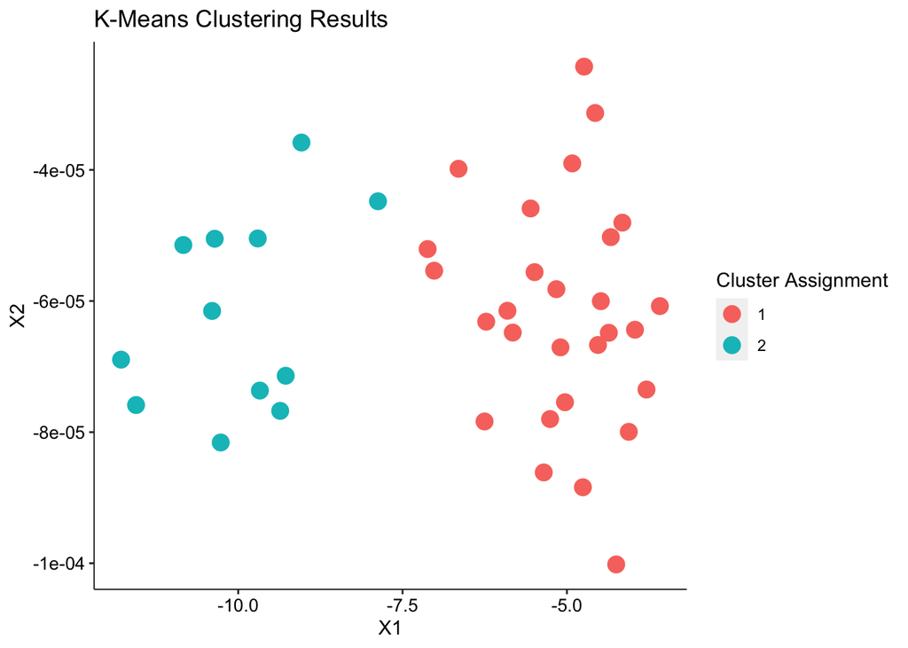

```r
dcf<-discrcoord(segments$util,segments$sclu)
assignments<-augment(segments$segm,dcf$proj[,1:2])
ggplot(assignments)+geom_point(aes(x=X1,y=X2,color= .cluster),size =4)+
  theme(panel.background = element_rect(fill="white"),axis.line = element_line(size=0.3,colour="black"),
        axis.text.x = element_text(size=10,colour="black"),
        axis.text.y = element_text(size=10,colour="black"))+
  labs(color="Cluster Assignment",title="K-Means Clustering Results")
```

## Market share analysis

Function to calculate market share percentage

```r
Market_share <- function(partworths,simulations) {
  # partworths could be the output from caPartUtilities()
  # simulations is bundles description (not coded version) with attribute name as the first column
  for (j in seq(1:length(colnames(simulations)))) {
    mylist<- c()
    for (i in seq(1:length(colnames(partworths)))) {
      coln <- colnames(partworths)[i]
      if (coln %in% simulations[,j] || coln == "intercept"){
        mylist<- c(mylist,coln)
        pat <- quo_name(enquo(j))
        newN <- paste0(pat, "_sum")
        newPref <-partworths %>%
          select(all_of(mylist)) %>%
          reduce(`+`)
        partworths<-partworths %>%
          mutate(!!newN := newPref)
      }
    }
  }
  new_preferances<-partworths[,17:ncol(partworths)]
  projected_purchase <-colnames(new_preferances)[apply(new_preferances, 1,which.max)]
  Purchase <-data.frame(table(projected_purchase))
  Purchase$projected_purchase <-colnames(simulations)
  Purchase <- Purchase %>% mutate(Purchase, share_percentage = (Purchase$Freq)*100/ sum(Purchase$Freq))
  Purchase$projected_purchase <- factor(Purchase$projected_purchase, levels = Purchase$projected_purchase)
  return(Purchase)
}
```

Market_share of Bundle09 when launched with existing profiles

```r
partworth_each <-as.data.frame(part_utilities) # partworths of each respondent : can use given values as well
simulation1<- cbind(existing_prof_data, bundles_data$Bundle09)[,-1]

existing_and_bundle9<-Market_share(partworth_each,simulation1)
existing_and_bundle9
```

```
##      projected_purchase Freq share_percentage
## 1 Courtyard_by_Marriott    6             15.0
## 2      Nittany_Lion_Inn    4             10.0
## 3       Atherton_Hilton    3              7.5
## 4              Toftrees   10             25.0
## 5             Scanticon   10             25.0
## 6 bundles_data$Bundle09    7             17.5
```

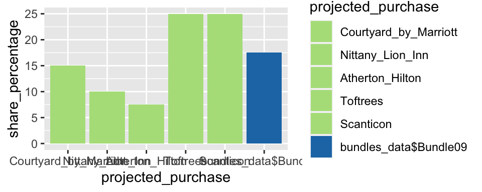

```r
#write.csv(existing_and_bundle9, "existing_and_bundle9_market_shares.csv")
p1<-ggplot(existing_and_bundle9, aes(x=projected_purchase,y=share_percentage,fill=projected_purchase)) + geom_bar(stat="identity")
p1<-p1+scale_fill_manual(values=c( "#b2df8a", "#b2df8a", "#b2df8a","#b2df8a","#b2df8a","#1f78b4"))
p1
```

Market_share of Bundle09 when launched with new profiles

```r
partworth_each <-as.data.frame(part_utilities) # partworths of each respondent : can use given values as well
simulation2<- cbind(new_prof_data, bundles_data$Bundle09)[,-1]

new_and_bundle9<-Market_share(partworth_each,simulation2)
new_and_bundle9
```

```
##      projected_purchase Freq share_percentage
## 1        Professional01    9             22.5
## 2        Professional02   10             25.0
## 3               Tourist    7             17.5
## 4                Deluxe    4             10.0
## 5 bundles_data$Bundle09   10             25.0
```

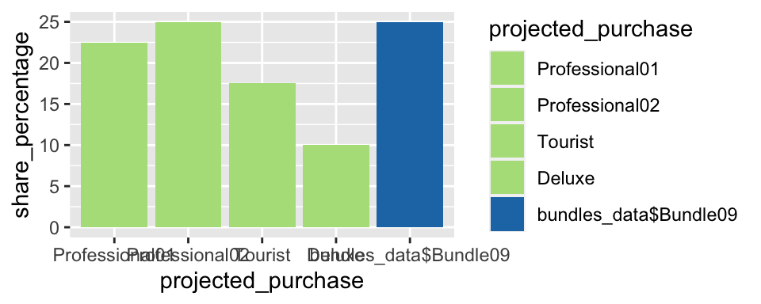

```r
#write.csv(new_and_bundle9, "new_and_bundle9_market_shares.csv")
p2<-ggplot(new_and_bundle9, aes(x=projected_purchase,y=share_percentage,fill=projected_purchase)) + geom_bar(stat="identity")
p2<-p2+scale_fill_manual(values=c( "#b2df8a", "#b2df8a", "#b2df8a","#b2df8a","#1f78b4"))
p2
```